# R Notebook

```r
library(tidyverse)
```

1. Read in `districts.csv` into a tibble named `districts`.

```r
districts <- read_csv("../data/districts.csv")
```

```r
districts
```

| system | system_name | alg_1 | alg_2 | bio | chem | ela | eng_1 | eng_2 | eng_3 | math | science | enrollment | black | hispanic | native | el | swd | ed | expenditures | act_composite | chronic_abs | suspended | expelled | grad | dropout | region |
| --- | --- | --- | --- | --- | --- | --- | --- | --- | --- | --- | --- | --- | --- | --- | --- | --- | --- | --- | --- | --- | --- | --- | --- | --- | --- | --- |
| 0 | State of Tennessee | 70.0 | 54.3 | 65.3 | 44.2 | 48.4 | 71.8 | 64.8 | 41.7 | 54.7 | 64.5 | 943699 | 24.1 | 8.5 | 0.3 | 4.6 | 14.0 | 57.9 | 9374.9 | 19.4 | 13.2 | 6.2 | 0.2 | 87.2 | 8.4 | NA |
| 10 | Anderson County | 76.1 | 63.3 | 73.6 | 41.0 | 45.7 | 73.7 | 59.2 | 38.2 | 54.0 | 64.5 | 6304 | 2.8 | 1.1 | 0.5 | 0.2 | 18.0 | 58.5 | 9535.7 | 19.9 | 11.5 | 5.0 | 0.1 | 94.0 | 4.2 | East TN |
| 11 | Clinton City | NA | NA | NA | NA | 58.3 | NA | NA | NA | 68.9 | 69.6 | 894 | 5.7 | 2.8 | 0.3 | 1.0 | 18.1 | 63.4 | 9537.5 | NA | 8.8 | 1.2 | 0.0 | NA | NA | East TN |
| 12 | Oak Ridge City | 76.9 | 72.0 | 83.5 | 80.9 | 56.1 | 86.7 | 74.6 | 53.8 | 55.3 | 70.8 | 4326 | 16.6 | 8.0 | 0.7 | 3.0 | 14.3 | 52.5 | 12355.5 | 23.1 | 17.5 | 5.7 | 0.0 | 89.7 | 4.4 | East TN |
| 20 | Bedford County | 64.3 | 42.4 | 62.1 | 32.5 | 44.1 | 72.3 | 63.1 | 44.6 | 53.1 | 61.8 | 8270 | 11.2 | 20.6 | 0.5 | 9.4 | 10.9 | 69.9 | 7756.2 | 18.4 | 8.6 | 2.2 | 0.0 | 90.8 | 5.4 | South Central |
| 30 | Benton County | 73.7 | 58.4 | 77.1 | 33.1 | 46.0 | 75.4 | 60.8 | 45.6 | 53.9 | 65.0 | 2133 | 3.9 | 2.1 | 0.3 | 0.0 | 18.8 | 50.2 | 9714.2 | 18.4 | 6.5 | 0.0 | 0.0 | 94.5 | 3.0 | Northwest |
| 40 | Bledsoe County | 64.8 | 73.9 | 73.0 | 19.5 | 35.4 | 63.6 | 53.3 | 50.0 | 41.1 | 56.2 | 1674 | 1.5 | 6.8 | 0.6 | 2.3 | 19.7 | 83.5 | 9495.9 | 19.2 | 9.1 | 2.4 | 0.1 | 92.4 | 6.9 | Upper Cumberland |
| 50 | Blount County | 73.2 | 59.8 | 65.1 | 45.4 | 46.3 | 71.8 | 66.0 | 45.3 | 50.5 | 68.4 | 10500 | 3.0 | 4.2 | 0.4 | 1.9 | 12.8 | 54.2 | 8866.9 | 19.7 | 17.0 | 4.7 | 0.1 | 89.1 | 9.2 | East TN |
| 51 | Alcoa City | 82.2 | 76.8 | 88.0 | 66.0 | 50.2 | 85.5 | 79.6 | 67.2 | 56.6 | 65.1 | 1850 | 23.3 | 9.5 | 0.6 | 2.7 | 13.0 | 49.4 | 10320.0 | 22.0 | 4.7 | 3.1 | 0.1 | 98.2 | 0.9 | East TN |
| 52 | Maryville City | 83.8 | 77.3 | 92.1 | 80.4 | 69.6 | 89.9 | 82.7 | 68.1 | 70.2 | 87.1 | 4944 | 4.2 | 4.0 | 0.2 | 2.8 | 13.2 | 32.1 | 10161.2 | 23.0 | 2.0 | 2.7 | 0.0 | 96.6 | 3.1 | East TN |

[output cut: 136 more lines]

2. Notice that the first row corresponds to the whole State of Tennessee. Remove this row and save the result back to `districts`.

```r
districts <- districts[-c(1), ]
districts
```

| system | system_name | alg_1 | alg_2 | bio | chem | ela | eng_1 | eng_2 | eng_3 | math | science | enrollment | black | hispanic | native | el | swd | ed | expenditures | act_composite | chronic_abs | suspended | expelled | grad | dropout | region |
| --- | --- | --- | --- | --- | --- | --- | --- | --- | --- | --- | --- | --- | --- | --- | --- | --- | --- | --- | --- | --- | --- | --- | --- | --- | --- | --- |
| 10 | Anderson County | 76.1 | 63.3 | 73.6 | 41.0 | 45.7 | 73.7 | 59.2 | 38.2 | 54.0 | 64.5 | 6304 | 2.8 | 1.1 | 0.5 | 0.2 | 18.0 | 58.5 | 9535.7 | 19.9 | 11.5 | 5.0 | 0.1 | 94.0 | 4.2 | East TN |
| 11 | Clinton City | NA | NA | NA | NA | 58.3 | NA | NA | NA | 68.9 | 69.6 | 894 | 5.7 | 2.8 | 0.3 | 1.0 | 18.1 | 63.4 | 9537.5 | NA | 8.8 | 1.2 | 0.0 | NA | NA | East TN |
| 12 | Oak Ridge City | 76.9 | 72.0 | 83.5 | 80.9 | 56.1 | 86.7 | 74.6 | 53.8 | 55.3 | 70.8 | 4326 | 16.6 | 8.0 | 0.7 | 3.0 | 14.3 | 52.5 | 12355.5 | 23.1 | 17.5 | 5.7 | 0.0 | 89.7 | 4.4 | East TN |
| 20 | Bedford County | 64.3 | 42.4 | 62.1 | 32.5 | 44.1 | 72.3 | 63.1 | 44.6 | 53.1 | 61.8 | 8270 | 11.2 | 20.6 | 0.5 | 9.4 | 10.9 | 69.9 | 7756.2 | 18.4 | 8.6 | 2.2 | 0.0 | 90.8 | 5.4 | South Central |
| 30 | Benton County | 73.7 | 58.4 | 77.1 | 33.1 | 46.0 | 75.4 | 60.8 | 45.6 | 53.9 | 65.0 | 2133 | 3.9 | 2.1 | 0.3 | 0.0 | 18.8 | 50.2 | 9714.2 | 18.4 | 6.5 | 0.0 | 0.0 | 94.5 | 3.0 | Northwest |
| 40 | Bledsoe County | 64.8 | 73.9 | 73.0 | 19.5 | 35.4 | 63.6 | 53.3 | 50.0 | 41.1 | 56.2 | 1674 | 1.5 | 6.8 | 0.6 | 2.3 | 19.7 | 83.5 | 9495.9 | 19.2 | 9.1 | 2.4 | 0.1 | 92.4 | 6.9 | Upper Cumberland |
| 50 | Blount County | 73.2 | 59.8 | 65.1 | 45.4 | 46.3 | 71.8 | 66.0 | 45.3 | 50.5 | 68.4 | 10500 | 3.0 | 4.2 | 0.4 | 1.9 | 12.8 | 54.2 | 8866.9 | 19.7 | 17.0 | 4.7 | 0.1 | 89.1 | 9.2 | East TN |
| 51 | Alcoa City | 82.2 | 76.8 | 88.0 | 66.0 | 50.2 | 85.5 | 79.6 | 67.2 | 56.6 | 65.1 | 1850 | 23.3 | 9.5 | 0.6 | 2.7 | 13.0 | 49.4 | 10320.0 | 22.0 | 4.7 | 3.1 | 0.1 | 98.2 | 0.9 | East TN |
| 52 | Maryville City | 83.8 | 77.3 | 92.1 | 80.4 | 69.6 | 89.9 | 82.7 | 68.1 | 70.2 | 87.1 | 4944 | 4.2 | 4.0 | 0.2 | 2.8 | 13.2 | 32.1 | 10161.2 | 23.0 | 2.0 | 2.7 | 0.0 | 96.6 | 3.1 | East TN |
| 60 | Bradley County | NA | 59.5 | 64.1 | 55.7 | 52.4 | 74.4 | 66.3 | 38.2 | 57.1 | 65.9 | 9801 | 3.6 | 4.3 | 0.3 | 1.6 | 11.3 | 55.1 | 8429.3 | 18.8 | 16.0 | 3.9 | 0.1 | 93.1 | 5.6 | Southeast |

[output cut: 135 more lines]

3. How many districts have a proficiency rate of at least 80% for both alg_1 and eng_1?

```r
districts |>
  filter(alg_1>=80 & eng_1>=80 ) |>
  count(system_name) |>
  summarise(total_districts = n())
```

| total_districts |
| --- |
| 13 |

4. How many districts have a proviciency rate less than 50% for either alg_1 or eng_1?

```r
districts |>
  filter(alg_1<50 | eng_1<50) |>
  count(system_name) |>
  summarise(total_districts = n())
```

| total_districts |
| --- |
| 8 |

5. Which district has the lowest graduation rate?

```r
districts |>
  select(system_name, grad) |>
  arrange(grad) |>
  slice_head(n=1)
```

| system_name | grad |
| --- | --- |
| Tenn School for Blind | 11.1 |

6. Within the Mid Cumberland region, which district has the highest ACT composite?

```r
districts |>
  filter(region == c('Mid Cumberland')) |>
  select(system_name, act_composite) |>
  arrange(desc(act_composite)) |>
  slice_head(n=1)
```

| system_name | act_composite |
| --- | --- |
| Williamson County | 23.8 |

```r
NA
NA
```

7. Create a scatter plot to compare alg_1 proficiency rates to alg_2 rates. What do you notice? Facet this plot by region. Does anything stand out when you facet the plots?

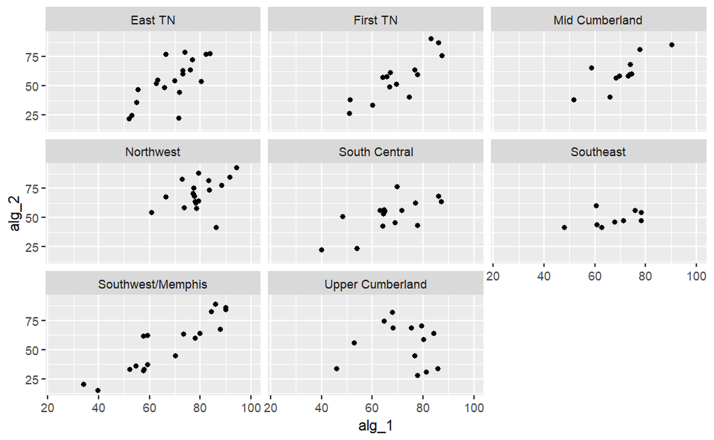

```r
ggplot(districts, aes(x=alg_1, y=alg_2)) +
  geom_point() +
  facet_wrap(~region)
```

Interpretation. There is a strong, positive correlation between higher grades in algebra 1 and algebra 2. If you score higher algebra 1, its postively associated with scoring higher in algebra 2 which makes sense. Some regions have stronger correlation between the two variables than others. Upper Cumberland appears to have no association.

```r
districts
```

| system | system_name | alg_1 | alg_2 | bio | chem | ela | eng_1 | eng_2 | eng_3 | math | science | enrollment | black | hispanic | native | el | swd | ed | expenditures | act_composite | chronic_abs | suspended | expelled | grad | dropout | region |
| --- | --- | --- | --- | --- | --- | --- | --- | --- | --- | --- | --- | --- | --- | --- | --- | --- | --- | --- | --- | --- | --- | --- | --- | --- | --- | --- |
| 10 | Anderson County | 76.1 | 63.3 | 73.6 | 41.0 | 45.7 | 73.7 | 59.2 | 38.2 | 54.0 | 64.5 | 6304 | 2.8 | 1.1 | 0.5 | 0.2 | 18.0 | 58.5 | 9535.7 | 19.9 | 11.5 | 5.0 | 0.1 | 94.0 | 4.2 | East TN |
| 11 | Clinton City | NA | NA | NA | NA | 58.3 | NA | NA | NA | 68.9 | 69.6 | 894 | 5.7 | 2.8 | 0.3 | 1.0 | 18.1 | 63.4 | 9537.5 | NA | 8.8 | 1.2 | 0.0 | NA | NA | East TN |
| 12 | Oak Ridge City | 76.9 | 72.0 | 83.5 | 80.9 | 56.1 | 86.7 | 74.6 | 53.8 | 55.3 | 70.8 | 4326 | 16.6 | 8.0 | 0.7 | 3.0 | 14.3 | 52.5 | 12355.5 | 23.1 | 17.5 | 5.7 | 0.0 | 89.7 | 4.4 | East TN |
| 20 | Bedford County | 64.3 | 42.4 | 62.1 | 32.5 | 44.1 | 72.3 | 63.1 | 44.6 | 53.1 | 61.8 | 8270 | 11.2 | 20.6 | 0.5 | 9.4 | 10.9 | 69.9 | 7756.2 | 18.4 | 8.6 | 2.2 | 0.0 | 90.8 | 5.4 | South Central |
| 30 | Benton County | 73.7 | 58.4 | 77.1 | 33.1 | 46.0 | 75.4 | 60.8 | 45.6 | 53.9 | 65.0 | 2133 | 3.9 | 2.1 | 0.3 | 0.0 | 18.8 | 50.2 | 9714.2 | 18.4 | 6.5 | 0.0 | 0.0 | 94.5 | 3.0 | Northwest |
| 40 | Bledsoe County | 64.8 | 73.9 | 73.0 | 19.5 | 35.4 | 63.6 | 53.3 | 50.0 | 41.1 | 56.2 | 1674 | 1.5 | 6.8 | 0.6 | 2.3 | 19.7 | 83.5 | 9495.9 | 19.2 | 9.1 | 2.4 | 0.1 | 92.4 | 6.9 | Upper Cumberland |
| 50 | Blount County | 73.2 | 59.8 | 65.1 | 45.4 | 46.3 | 71.8 | 66.0 | 45.3 | 50.5 | 68.4 | 10500 | 3.0 | 4.2 | 0.4 | 1.9 | 12.8 | 54.2 | 8866.9 | 19.7 | 17.0 | 4.7 | 0.1 | 89.1 | 9.2 | East TN |
| 51 | Alcoa City | 82.2 | 76.8 | 88.0 | 66.0 | 50.2 | 85.5 | 79.6 | 67.2 | 56.6 | 65.1 | 1850 | 23.3 | 9.5 | 0.6 | 2.7 | 13.0 | 49.4 | 10320.0 | 22.0 | 4.7 | 3.1 | 0.1 | 98.2 | 0.9 | East TN |
| 52 | Maryville City | 83.8 | 77.3 | 92.1 | 80.4 | 69.6 | 89.9 | 82.7 | 68.1 | 70.2 | 87.1 | 4944 | 4.2 | 4.0 | 0.2 | 2.8 | 13.2 | 32.1 | 10161.2 | 23.0 | 2.0 | 2.7 | 0.0 | 96.6 | 3.1 | East TN |
| 60 | Bradley County | NA | 59.5 | 64.1 | 55.7 | 52.4 | 74.4 | 66.3 | 38.2 | 57.1 | 65.9 | 9801 | 3.6 | 4.3 | 0.3 | 1.6 | 11.3 | 55.1 | 8429.3 | 18.8 | 16.0 | 3.9 | 0.1 | 93.1 | 5.6 | Southeast |

[output cut: 135 more lines]

```r
districts |>
 select(system_name, enrollment) |>
 subset(is.na(enrollment)) |>
 summarise(total_count = n())
```

| total_count |
| --- |
| 4 |

```r
NA
NA
```

9. A lot of rows are missing additional values. Which district has the largest number of missing values (across all variables)? Hint: you might want to look at rowwise and c_across to answer this question.

```r
districts <- districts |>
  rowwise() |> # this is a group_by() function by row.
  mutate(count_na = sum(is.na(cur_data())))
```

```r
districts |>
  select(count_na, system_name) |>
  arrange(desc(count_na)) |>
  head(1)
```

| count_na | system_name |
| --- | --- |
| 15 | West Tenn School for Deaf |

10. What is the mean graduation rate across all districts? What might be wrong with using just the regular mean to assess average graduation rates?

```r
districts |>
  group_by(grad)
```

| system | system_name | alg_1 | alg_2 | bio | chem | ela | eng_1 | eng_2 | eng_3 | math | science | enrollment | black | hispanic | native | el | swd | ed | expenditures | act_composite | chronic_abs | suspended | expelled | grad | dropout | region | count_na |
| --- | --- | --- | --- | --- | --- | --- | --- | --- | --- | --- | --- | --- | --- | --- | --- | --- | --- | --- | --- | --- | --- | --- | --- | --- | --- | --- | --- |
| 10 | Anderson County | 76.1 | 63.3 | 73.6 | 41.0 | 45.7 | 73.7 | 59.2 | 38.2 | 54.0 | 64.5 | 6304 | 2.8 | 1.1 | 0.5 | 0.2 | 18.0 | 58.5 | 9535.7 | 19.9 | 11.5 | 5.0 | 0.1 | 94.0 | 4.2 | East TN | 0 |
| 11 | Clinton City | NA | NA | NA | NA | 58.3 | NA | NA | NA | 68.9 | 69.6 | 894 | 5.7 | 2.8 | 0.3 | 1.0 | 18.1 | 63.4 | 9537.5 | NA | 8.8 | 1.2 | 0.0 | NA | NA | East TN | 10 |
| 12 | Oak Ridge City | 76.9 | 72.0 | 83.5 | 80.9 | 56.1 | 86.7 | 74.6 | 53.8 | 55.3 | 70.8 | 4326 | 16.6 | 8.0 | 0.7 | 3.0 | 14.3 | 52.5 | 12355.5 | 23.1 | 17.5 | 5.7 | 0.0 | 89.7 | 4.4 | East TN | 0 |
| 20 | Bedford County | 64.3 | 42.4 | 62.1 | 32.5 | 44.1 | 72.3 | 63.1 | 44.6 | 53.1 | 61.8 | 8270 | 11.2 | 20.6 | 0.5 | 9.4 | 10.9 | 69.9 | 7756.2 | 18.4 | 8.6 | 2.2 | 0.0 | 90.8 | 5.4 | South Central | 0 |
| 30 | Benton County | 73.7 | 58.4 | 77.1 | 33.1 | 46.0 | 75.4 | 60.8 | 45.6 | 53.9 | 65.0 | 2133 | 3.9 | 2.1 | 0.3 | 0.0 | 18.8 | 50.2 | 9714.2 | 18.4 | 6.5 | 0.0 | 0.0 | 94.5 | 3.0 | Northwest | 0 |
| 40 | Bledsoe County | 64.8 | 73.9 | 73.0 | 19.5 | 35.4 | 63.6 | 53.3 | 50.0 | 41.1 | 56.2 | 1674 | 1.5 | 6.8 | 0.6 | 2.3 | 19.7 | 83.5 | 9495.9 | 19.2 | 9.1 | 2.4 | 0.1 | 92.4 | 6.9 | Upper Cumberland | 0 |
| 50 | Blount County | 73.2 | 59.8 | 65.1 | 45.4 | 46.3 | 71.8 | 66.0 | 45.3 | 50.5 | 68.4 | 10500 | 3.0 | 4.2 | 0.4 | 1.9 | 12.8 | 54.2 | 8866.9 | 19.7 | 17.0 | 4.7 | 0.1 | 89.1 | 9.2 | East TN | 0 |
| 51 | Alcoa City | 82.2 | 76.8 | 88.0 | 66.0 | 50.2 | 85.5 | 79.6 | 67.2 | 56.6 | 65.1 | 1850 | 23.3 | 9.5 | 0.6 | 2.7 | 13.0 | 49.4 | 10320.0 | 22.0 | 4.7 | 3.1 | 0.1 | 98.2 | 0.9 | East TN | 0 |
| 52 | Maryville City | 83.8 | 77.3 | 92.1 | 80.4 | 69.6 | 89.9 | 82.7 | 68.1 | 70.2 | 87.1 | 4944 | 4.2 | 4.0 | 0.2 | 2.8 | 13.2 | 32.1 | 10161.2 | 23.0 | 2.0 | 2.7 | 0.0 | 96.6 | 3.1 | East TN | 0 |
| 60 | Bradley County | NA | 59.5 | 64.1 | 55.7 | 52.4 | 74.4 | 66.3 | 38.2 | 57.1 | 65.9 | 9801 | 3.6 | 4.3 | 0.3 | 1.6 | 11.3 | 55.1 | 8429.3 | 18.8 | 16.0 | 3.9 | 0.1 | 93.1 | 5.6 | Southeast | 1 |

[output cut: 135 more lines]

```r
  summary(districts$grad)
```

```
   Min. 1st Qu.  Median    Mean 3rd Qu.    Max.    NA's
  11.10   87.67   91.50   90.07   94.90  100.00      17
```